# Stat159 Homework 3 Report

Andrew Shibata

October 14, 2016

# Abstract

This report replicates section 3.2 (Multiple Linear Regression) of the book *An Introduction to Statistical Learning*.

Concepts covered by this assignment include performing multiple regression analysis in R and using the package testthat.

# Introduction

This report analyzes the effects of different types of advertisement media on the overall sales of of a product. In the last assignment we only looked at the linear regression for Sales by TV, but now we will additionally perform a multiple regression analysis with all 3 advertising factors.

# Data

Similarly to Homework 2, this assignment deals with the *Advertising.csv* dataset. It contains information about the advertising budgets for *TV*, *Radio*, and *Newspaper* advertisements as well as the resulting *Sales* in 200 markets.

Additionally, here are the histograms of the distributions: Histogram of TV Budgets

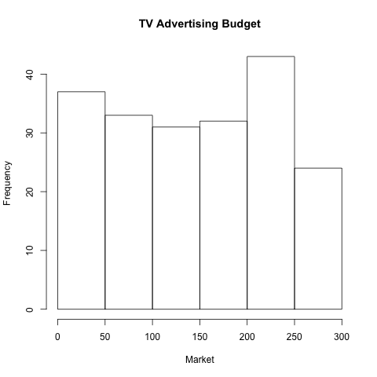

Histogram of Radio Budgets

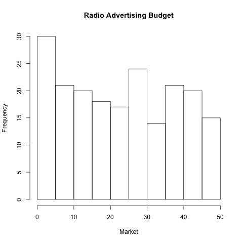

Histogram of Newspaper Budgets

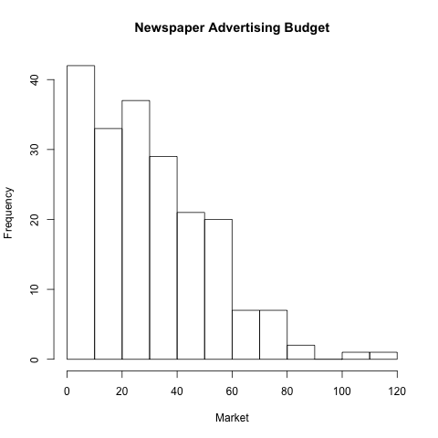

Histogram of Sales

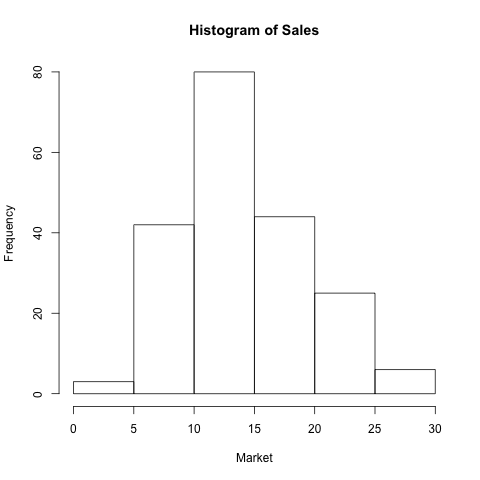

# Methodology

*Single Linear Regression* From Homework 2, looking at the effect of either *TV*, *Radio*, or *Newspaper* on *Sales* is a single linear regression in which expected Sales is predicted from a given advertising medium.

This follows the form:

$$Sales = \beta_{0} + \beta_{1}*(TV/Radio/Newspaper)$$

*Mutliple Linear Regression* Now, we look at the combined effects of TV, Radio, and Newspaper marketing on Sales so we perform a multiple linear regression model which follows the form:

$$Sales = \beta_{0} + \beta_{1}*TV + \beta_{2}*Radio + \beta_{3}*Newspaper$$

# Results

*Regression of Sales by Radio*

*Regression of Sales by Newspaper*

Here is the scatter plot with the least squares regression line:

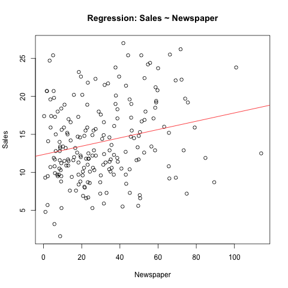

The regression line does not seem to really fit the relationship between Newspaper and Sales so linear regresison may not be appropriate.

## Multiple Linear Regression

Here is the qq-plot for the residuals:

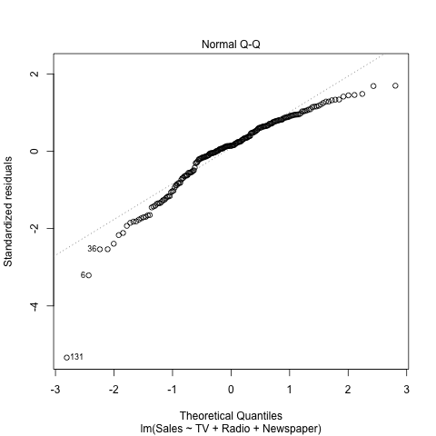

#Conclusion